# Manual - Economatica

# Etapa 5 - Exportação de Dados

Por fim, podemos *exportar* os dados coletados para realizar a análise em outros softwares mais especializados, proporcionando uma análise mais aprofundada. Para realizar a exportação, selecionamos a opção destacada em vermelho, no canto superior direito.

[figure not shown]

Logo após, selecionamos a opção exportar.

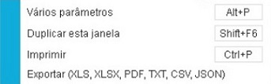

Por fim, selecionamos as opções de exportação.

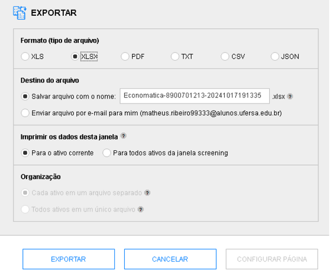

Podemos exportar em vários formatos de arquivo, como CSV, XLSX, PDF, entre outros. No nosso caso, vamos exportar em CSV, conforme mostrado abaixo. Podemos escolher o nome do arquvo para salvar ou enviá-lo para um e-mail selecionado.

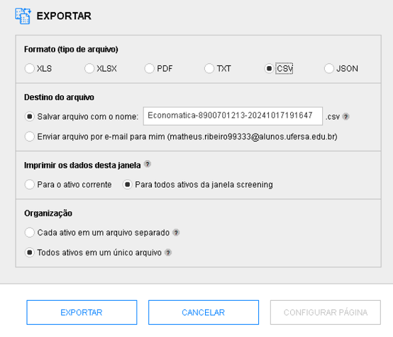

Seus dados estarão dispostos na estrutura de dados em painel no Excel ou em outra ferramenta de planilhas ou análise de dados.

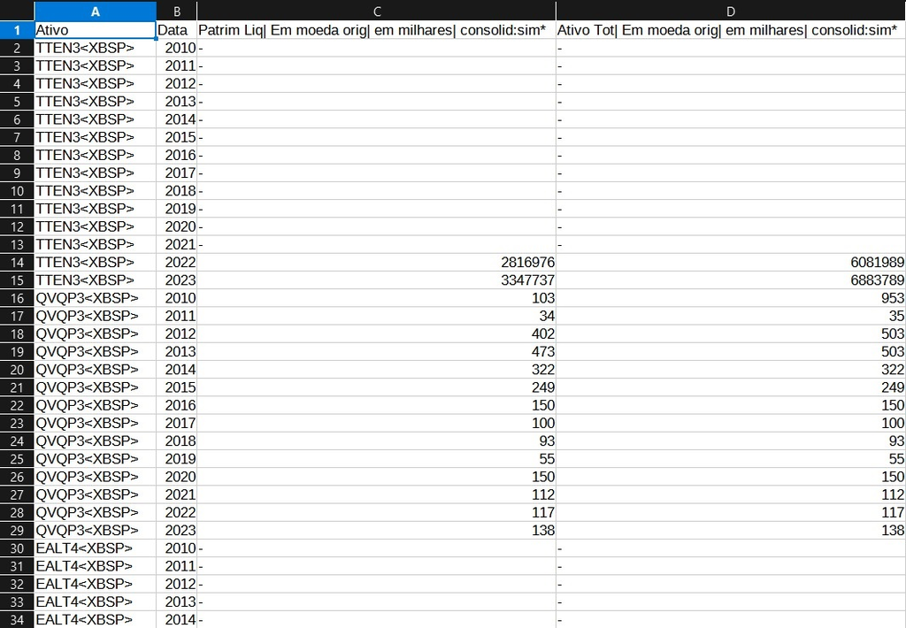

E este é o fim do tutorial. Esperamos que ele sirva de base para a realização de seu trabalho. Importante frisar que este tutoral buscou utilizar exemplos práticos para melhor entendimento, cabendo salientar que o usuário pode escolher os dados que são mais relevantes para a sua pesquisa, não estando limitados ao que foi apresentado.

Autores:

Marcos Thiago Martins

Matheus Juan Silva Ribeiro